# Analysis of Zach Poss’ SY351 (Syros covalent CDK7 inhibitor) treated HL-60 proteome SILAC data

William M. Old, Zachary Poss, Jeremy Jacobsen

March 19, 2020

This is the fifth of five R markdown (Rmd) files used to generate vignettes in the SY351SILAC data package:

1. parse_process_phosphodata_SY351_1hr_HL60_PhosphoSILAC_ZPoss_WOld.Rmd
2. analyze_phospho_data_SY351_1hr_HL60_PhosphoSILAC_ZPoss_WOld.Rmd
3. make_site_table_SY351_1hr_HL60_PhosphoSILAC_ZPoss_WOld.Rmd
4. prepare_analyze_momo_motif_analysis.Rmd
5. **parse_analyze_proteomedata_SY351_1hr_HL60_PhosphoSILAC.Rmd**

### Read in proteome data into the proteinratios data frame (tbl_df)

```r
protcols <- unlist(strsplit( readLines(gzfile(fpath) ,n  =  1),"\t"))
#
dattypes <- grep("\\{Type\\}", readLines(gzfile(fpath) ,n  =  2), value = T)
dattypes <- unlist(strsplit( gsub("#!\\{Type\\}","",dattypes),"\t"))
#
mqdatacolnms <- protcols[dattypes == "E"]
#mqdatacolnms should be   c("null","rep1","rep2","rep3LF")

# proteinratios <- read.table(fpath,
#                             header=T,
#                             stringsAsFactors=F,
#                             na.strings="NaN",
#                             quote = "\"",
#                             sep="\t",
#                             fill = T)

proteinratios_df_list <- read_maxquant_proteingroupfile(proteinGroups.filename = fpath,
                                    datacolnames = mqdatacolnms,
                                    uniprot.acc.column = "Majority protein IDs",
                                    uniprot.id.column = "UniProt names",
                                    datacolumnprefix = "",
                                    log2.transform = F,
                                    is.label.free = T,
                                    is.gzip.file = T)


prot_colnms <- proteinratios_df_list$prot.colnms
proteinratios <- proteinratios_df_list$prot.table %>% tibble::as_tibble()
```

### Set up the targets_proteins data frame

This sets up the target matrix that maps sample names with sample SILAC ratios (column names in PhosphoSTY.txt file) and which samples were labeled with what SILAC label. Make sure the the target data frame has two columns: Light and Heavy which indicates the sample’s SILAC label. targets_proteins. e.g. for a label-swap design.

```r
# This sets up the columns for the design matrix "design" uses the limma two color functionality to
# model the two SILAC channels heavy and light. The design includes a flipped SILAC analysis
# for harmine treatment on light cells, with DMSO treated heavy,
# as well as a null effect, for DMSO treatment of both. We have noticed that in some cell lines
# there are label specific differences in protein expression that must be controlled for.

targets_proteins <- data.frame(samples = prot_colnms,
                      Light = c("DMSO","DMSO","DMSO","SY351"),
                      Heavy  = c("DMSO","SY351","SY351","DMSO"))
targets_proteins
```

```
##   samples Light Heavy
## 1    null  DMSO  DMSO
## 2    rep1  DMSO SY351
## 3    rep2  DMSO SY351
## 4  rep3LF SY351  DMSO
```

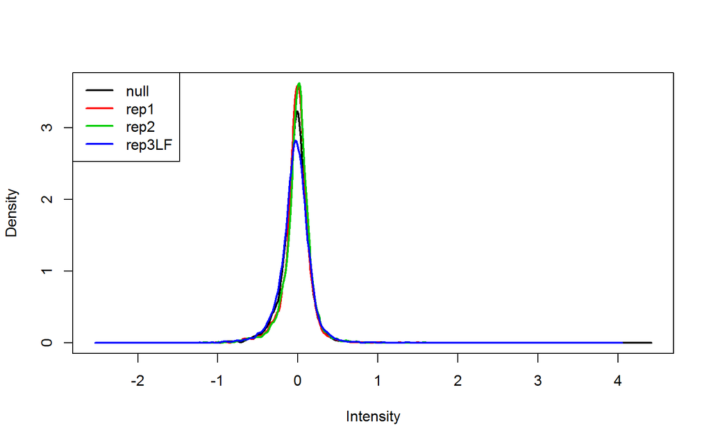

```r
plotDensities(proteinratios[,prot_colnms])
```

```r
# Copy ratio columns to a new set of columns representing unnormalized ratios (*_nonorm)
nonorm <- function(x) {x}

proteinratios <- proteinratios %>% mutate_at(vars(targets_proteins$samples), .funs = list(nonorm = ~nonorm(.) ))

proteinratios[,targets_proteins$samples]  <- limma::normalizeBetweenArrays(proteinratios[,targets_proteins$samples],method = "cyclicloess")

proteinratios[,prot_colnms] <- normalizeBetweenArrays(proteinratios[,prot_colnms],method = "quantile")

proteinratios[,prot_colnms] <- normalizeBetweenArrays(proteinratios[,prot_colnms],method = "cyclicloess")


proteinratios$numvalid <- apply(proteinratios[,prot_colnms], 1, function(x) sum(!is.na(x)))
table(proteinratios$numvalid)
```

```
##
##    1    2    3    4
##  433  398  433 5512
```

### Set up model matrix

The first design matrix “design” has just one coefficient (1st and only column) that captures the log2(SY351/DMSO) effect. The next design matrix “design.isotopeffect” The first coeficient (first column) is the systematic “isotope effect”, which in this context is the systematic difference in the Heavy vs. Light effect superimposed on all the other treatments, modeled as an intercept coefficient. The second coefficient (column 2) is the log2(SY351/DMSO) effect. This alternative design has improved statistical power due to explicit modeling of the isotope labeling effect. We hypothesize that this effect, which we have observed in independent experiments with multiple cell lines, is due to protein expression changes in the independent cell populations that diverge during the amino acid labeling.

```r
design <- silac_model_matrix(targets_proteins, ref = "DMSO")
```

```
## Found unique target names:
##  DMSO SY351
```

```r
design <- cbind(rep(1,length(targets_proteins$samples)), design)
colnames(design) <- c("isotope","SY351")
design
```

```
##      isotope SY351
## [1,]       1     0
## [2,]       1     1
## [3,]       1     1
## [4,]       1    -1
```

```r
# In case NA's are not filtered out in source file from Perseus, this condition is used to only
# use rows that have at least 2 valid log2 ratios
selectedrows <- proteinratios$numvalid >= numvalid_thresh

# selectedrows.nullfilt <- proteinratios$numvalid >= numvalid_thresh &
#   !is.na(proteinratios$null) & abs(proteinratios$null) < abs_null_log2ratio_thresh

sklm <- lmFit(proteinratios[selectedrows,prot_colnms], design)
sklm$Amean <- log10(proteinratios$Intensity[selectedrows])


meta.names <- c("id",prot_colnms, 'Gene.name',"uniprot.id","uniprot.acc", "Protein.name", "Corum")

#meta.names[!meta.names %in% names(proteinratios)]

#names(proteinratios)[! names(proteinratios) %in% meta.names]
```

Make sure you have sourced the “get_toptable.R” script to define this function. This model incorporates an isotope effect, with two coefficients, Use the second coefficient for the log2(SY351/DMSO) effect. If you want to see the isotope label effect, you could call the function with coef = 1 in those cases.

```r
proteinratiosfit <- eBayes(sklm, trend = T)


proteinstats <- get_toptable(proteinratiosfit,
                             coef = "SY351",
                             glist = proteinratios[selectedrows,meta.names],
                             suffix = "")

sum(proteinstats$adj.P.Val < fdr.thresh,na.rm=T)
```

```
## [1] 6
```

```r
isotopeeffectstats <- topTable(proteinratiosfit,coef = "isotope", genelist = proteinratios[selectedrows,meta.names],number = Inf,p.value = 1)
```

### Write out data to files in a subdirectory named for current date

Change chunk option eval = T if you’d like to write out these files

```r
write.table(proteinstats,file='DiffsTable_ProteinChanges_Syros_SY351_eBayes_WOld_2020.txt',quote = F,sep = '\t',
            na = "",row.names = F,col.names = T)
write.table(names(proteinstats), file='DiffsTable_ProteinChanges_Syros_SY351_colnames_metadata_2020.txt', col.names = F, row.names = F, quote = F)
```

### Plot volcano plot for protein SILAC ratios showing changes in abundance with SY-351 treatment (HL-60 cells)

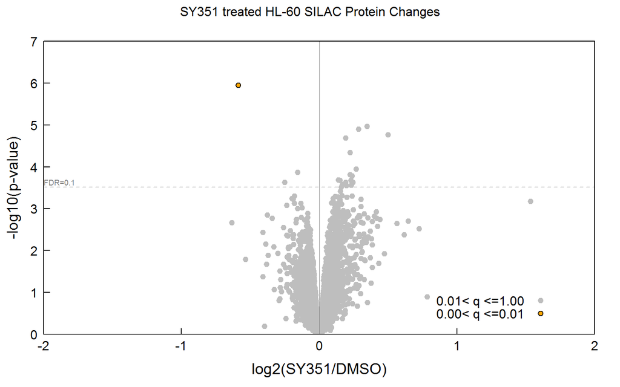

```r
my.fdr.range.cut <-  c(0,0.01,1)
proteinstats$fdr.range <- fdrcut(proteinstats$adj.P.Val, my.fdr.range.cut)
proteinstats$logp <- -log10(proteinstats$P.Value)

logpFDRmin.05 <-   min(proteinstats$logp[proteinstats$adj.P.Val < 0.05 & !is.na(proteinstats$adj.P.Val)], na.rm=T)
logpFDRmin.1 <-   min(proteinstats$logp[proteinstats$adj.P.Val < 0.1 & !is.na(proteinstats$adj.P.Val)], na.rm=T)

xax <- c(-2.0, -1.0, 0,
         1.0, 2.0)
yax <- c(0:7)



proteinvolcano <-  xyplot(logp ~ logFC, groups = fdr.range, data = proteinstats,
                          main = "SY351 treated HL-60 SILAC Protein Changes",
                          auto.key = list(x = 0.7, y = 0.05, corner = c(0, 0), cex = 1),
                      xlim = range(xax),ylim = range(yax),
                      xlab=list(label = "log2(SY351/DMSO)",cex = 1.2),
                      ylab=list(label = "-log10(p-value)",cex = 1.2),
                      scales=list(alternating = 1,
                                       x = list(at = xax, labels = as.character(xax),
                                                cex = 1.0, tck = c(-1,0)),
                                       y = list(at = yax, labels = as.character(yax),
                                                tick.number = 5, axs="i",
                                                cex = 1.0,tck = c(-1,0))
                                  ),
                      panel = function(...) {
                            panel.abline(h=logpFDRmin.1, lty=2, col='gray80')
                            panel.xyplot(...)
                            panel.abline(v = 0, lty = 1, lwd=0.5, col = 'gray50')
                            grid.text("FDR=0.1",
                                      x=unit(-2, "native"),
                                      y=unit(logpFDRmin.1+0.05, "native"),
                                      just=c("left","bottom"),
                                      gp=gpar(fontsize=7, col="grey50")
                                      )
                      })



s <- trellis.par.get("superpose.symbol")
s$pch <- c(19,21,21)

s$cex <- 0.8
s$alpha <- 1
s$fill <-  c('grey','orange','red')
s$col <- c('grey', 'black', 'black')
trellis.par.set("superpose.symbol",s)
trellis.par.set(add.text=list(cex = 1,col="black"))
trellis.par.set(par.main.text = list(lineheight = 1, col='black',font=1,cex=1)  )

#+ fig.width=10, fig.height=12
print(proteinvolcano)
```

```r
# # Uncomment these lines if you want to interactively label the points in the
# # volcano plot. In this case, make sure you uncomment the windows() command above.
# trellis.focus("panel", 1, 1)
# ids <- panel.identify(proteinstats$logp ~ proteinstats$logFC  ,labels = proteinstats$Gene.name,cex=1,col='red')
# trellis.unfocus()


proteinstats %>% mutate(Protein.name = str_trunc(Protein.name, width = 25),
                        Corum = str_trunc(Corum, width = 10)) %>%
  dplyr::arrange(adj.P.Val) %>% dplyr::top_n(n = 50, wt = dplyr::desc(adj.P.Val)) %>%
  kable(digits = 2) %>%
  kable_styling(bootstrap_options =
                  c("striped", "hover", "condensed", "responsive"),
                font_size = 10) %>%
  scroll_box(width = "100%", height = "800px")
```

| id | null | rep1 | rep2 | rep3LF | Gene.name | uniprot.id | uniprot.acc | Protein.name | Corum | logFC | CI.L | CI.R | AveExpr | t | P.Value | adj.P.Val | B | s2.post | sigma | fdr.range | logp |
| --- | --- | --- | --- | --- | --- | --- | --- | --- | --- | --- | --- | --- | --- | --- | --- | --- | --- | --- | --- | --- | --- |
| 1328 | -0.11 | -0.61 | -0.65 | 0.56 | SLC2A14 | GTR14_HUMAN | P11169 | Solute carrier family … |  | -0.59 | -0.67 | -0.50 | 9.25 | -16.78 | 0 | 0.01 | 4.79 | 0.00 | 0.05 | 0.00< q <=0.01 | 5.95 |
| 2589 | -0.28 | 0.00 | 0.08 | -0.66 | RPS28 | RS28_HUMAN | P62857 | 40S ribosomal protein S28 | 40S rib… | 0.35 | 0.28 | 0.42 | 9.55 | 11.81 | 0 | 0.02 | 3.51 | 0.00 | 0.04 | 0.01< q <=1.00 | 4.97 |
| 3569 | -0.43 | -0.24 | -0.21 | -0.61 | HLA-C | 1C02_HUMAN | Q29963 | HLA class I histocompa… |  | 0.19 | 0.15 | 0.24 | 10.24 | 10.67 | 0 | 0.02 | 3.07 | 0.00 | 0.02 | 0.01< q <=1.00 | 4.69 |
| 7709 | -0.33 | -0.04 | -0.02 | -0.60 | PIN4 | PIN4_HUMAN | Q9Y237 | Peptidyl-prolyl cis-tr… | Parvuli… | 0.29 | 0.23 | 0.35 | 9.60 | 11.52 | 0 | 0.02 | 3.41 | 0.00 | 0.01 | 0.01< q <=1.00 | 4.90 |
| 7869 | -0.53 | -0.03 | NA | -1.03 | RPL36 | RL36_HUMAN | Q9Y3U8 | 60S ribosomal protein L36 | 60S rib… | 0.50 | 0.41 | 0.59 | 9.34 | 13.42 | 0 | 0.02 | 2.53 | 0.00 | 0.00 | 0.01< q <=1.00 | 4.76 |
| 5469 | -0.08 | 0.21 | 0.21 | -0.22 | LRRC59 | LRC59_HUMAN | Q96AG4 | Leucine-rich repeat-co… |  | 0.22 | 0.17 | 0.28 | 10.16 | 9.40 | 0 | 0.04 | 2.48 | 0.00 | 0.05 | 0.01< q <=1.00 | 4.35 |
| 71 | -0.08 | -0.22 | -0.18 | 0.32 | NCF1 | NCF1_HUMAN | A8MVU1 | Neutrophil cytosol fac… |  | -0.25 | -0.33 | -0.17 | 9.88 | -7.19 | 0 | 0.09 | 1.13 | 0.00 | 0.08 | 0.01< q <=1.00 | 3.63 |
| 150 | -0.31 | 0.04 | 0.11 | -0.44 | NACA | NACA_HUMAN | Q13765 | Nascent polypeptide-as… |  | 0.27 | 0.19 | 0.35 | 10.16 | 8.11 | 0 | 0.09 | 1.75 | 0.00 | 0.08 | 0.01< q <=1.00 | 3.95 |
| 408 | -0.05 | -0.22 | -0.21 | 0.10 | SLC16A3 | MOT4_HUMAN | O15427 | Monocarboxylate transp… |  | -0.16 | -0.20 | -0.11 | 9.95 | -7.88 | 0 | 0.09 | 1.60 | 0.00 | 0.01 | 0.01< q <=1.00 | 3.87 |
| 720 | -0.51 | -0.32 | -0.22 | -0.66 | FLNB | FLNB_HUMAN | O75369-2 | Filamin-B |  | 0.20 | 0.13 | 0.27 | 9.87 | 6.98 | 0 | 0.09 | 0.97 | 0.00 | 0.06 | 0.01< q <=1.00 | 3.56 |
| 864 | -0.28 | -0.03 | -0.02 | -0.49 | TOX4 | TOX4_HUMAN | O94842-3 | TOX high mobility grou… |  | 0.23 | 0.15 | 0.31 | 9.18 | 6.99 | 0 | 0.09 | 0.98 | 0.00 | 0.01 | 0.01< q <=1.00 | 3.56 |
| 1722 | -0.12 | 0.02 | -0.02 | -0.28 | RPL10 | RL10_HUMAN | P27635 | 60S ribosomal protein L10 | 60S rib… | 0.14 | 0.09 | 0.18 | 10.23 | 7.35 | 0 | 0.09 | 1.24 | 0.00 | 0.02 | 0.01< q <=1.00 | 3.69 |
| 2169 | -0.35 | -0.12 | -0.15 | -0.58 | CEBPA | CEBPA_HUMAN | P49715-2 | CCAAT/enhancer-binding… | C/EBPal… | 0.22 | 0.15 | 0.29 | 9.37 | 7.69 | 0 | 0.09 | 1.48 | 0.00 | 0.02 | 0.01< q <=1.00 | 3.81 |
| 2578 | -0.33 | -0.07 | 0.07 | -0.47 | RPL23A | RL23A_HUMAN | P62750 | 60S ribosomal protein … | 60S rib… | 0.24 | 0.16 | 0.33 | 10.52 | 7.18 | 0 | 0.09 | 1.12 | 0.00 | 0.09 | 0.01< q <=1.00 | 3.63 |
| 2623 | -0.18 | 0.12 | 0.20 | -0.28 | RPS21 | RS21_HUMAN | P63220 | 40S ribosomal protein S21 | 40S rib… | 0.23 | 0.16 | 0.31 | 10.58 | 7.31 | 0 | 0.09 | 1.21 | 0.00 | 0.08 | 0.01< q <=1.00 | 3.68 |
| 2695 | -0.12 | 0.11 | 0.13 | -0.20 | SARNP | SARNP_HUMAN | P82979 | SAP domain-containing … |  | 0.17 | 0.11 | 0.23 | 10.14 | 7.05 | 0 | 0.09 | 1.02 | 0.00 | 0.05 | 0.01< q <=1.00 | 3.58 |
| 3196 | -0.12 | 0.09 | 0.07 | -0.21 | UBAP2L | UBP2L_HUMAN | Q14157 | Ubiquitin-associated p… | CPSF6-E… | 0.15 | 0.10 | 0.20 | 10.28 | 7.30 | 0 | 0.09 | 1.21 | 0.00 | 0.04 | 0.01< q <=1.00 | 3.67 |
| 3933 | -0.30 | -0.02 | -0.07 | -0.42 | FAM21A | FA21A_HUMAN | Q641Q2 | WASH complex subunit F… |  | 0.19 | 0.13 | 0.26 | 9.80 | 7.16 | 0 | 0.09 | 1.11 | 0.00 | 0.05 | 0.01< q <=1.00 | 3.63 |
| 6287 | 0.60 | 0.85 | 0.86 | 0.38 | REPIN1 | REPI1_HUMAN | Q9BWE0 | Replication initiator 1 |  | 0.24 | 0.16 | 0.31 | 9.26 | 7.61 | 0 | 0.09 | 1.42 | 0.00 | 0.01 | 0.01< q <=1.00 | 3.78 |
| 2383 | -0.14 | 0.05 | 0.08 | -0.24 | PSMD4 | PSMD4_HUMAN | P55036 | 26S proteasome non-ATP… | 26S pro… | 0.16 | 0.10 | 0.21 | 9.87 | 6.85 | 0 | 0.09 | 0.87 | 0.00 | 0.03 | 0.01< q <=1.00 | 3.51 |
| 3730 | -0.03 | 0.14 | 0.19 | -0.14 | ZNF326 | ZN326_HUMAN | Q5BKZ1 | DBIRD complex subunit … |  | 0.15 | 0.10 | 0.21 | 9.93 | 6.62 | 0 | 0.11 | 0.69 | 0.00 | 0.04 | 0.01< q <=1.00 | 3.42 |
| 250 | -0.30 | -0.38 | -0.46 | -0.05 | SCD | ACOD_HUMAN | O00767 | Acyl-CoA desaturase |  | -0.18 | -0.25 | -0.11 | 9.77 | -6.31 | 0 | 0.11 | 0.44 | 0.00 | 0.05 | 0.01< q <=1.00 | 3.30 |
| 412 | -0.13 | 0.07 | 0.06 | -0.20 | CD3EAP | RPA34_HUMAN | O15446 | DNA-directed RNA polym… | TNF-alp… | 0.14 | 0.08 | 0.19 | 10.18 | 6.26 | 0 | 0.11 | 0.40 | 0.00 | 0.04 | 0.01< q <=1.00 | 3.28 |
| 1074 | -0.27 | -0.35 | -0.47 | -0.02 | SERPINA1 | A1AT_HUMAN | P01009 | Alpha-1-antitrypsin;Sh… | SERPINA… | -0.19 | -0.26 | -0.12 | 9.84 | -6.11 | 0 | 0.11 | 0.27 | 0.00 | 0.07 | 0.01< q <=1.00 | 3.22 |
| 1184 | -0.32 | -0.25 | -0.25 | -0.57 | DBI | ACBP_HUMAN | P07108 | Acyl-CoA-binding protein |  | 0.15 | 0.09 | 0.21 | 10.54 | 6.11 | 0 | 0.11 | 0.27 | 0.00 | 0.06 | 0.01< q <=1.00 | 3.22 |
| 1324 | 0.18 | 0.31 | 0.30 | 0.13 | HSPA5 | GRP78_HUMAN | P11021 | 78 kDa glucose-regulat… | CEN com… | 0.09 | 0.05 | 0.13 | 11.44 | 5.91 | 0 | 0.11 | 0.09 | 0.00 | 0.02 | 0.01< q <=1.00 | 3.14 |
| 1381 | -0.01 | 0.16 | 0.27 | -0.27 | LAMP2 | LAMP2_HUMAN | P13473-2 | Lysosome-associated me… |  | 0.24 | 0.15 | 0.33 | 9.18 | 6.31 | 0 | 0.11 | 0.44 | 0.00 | 0.05 | 0.01< q <=1.00 | 3.30 |
| 1454 | -0.12 | -0.03 | 0.03 | -0.23 | RPS2 | RS2_HUMAN | P15880 | 40S ribosomal protein S2 | 40S rib… | 0.12 | 0.07 | 0.16 | 10.61 | 6.29 | 0 | 0.11 | 0.42 | 0.00 | 0.03 | 0.01< q <=1.00 | 3.29 |
| 1562 | -0.22 | -0.30 | -0.38 | 0.07 | NCF2 | NCF2_HUMAN | P19878 | Neutrophil cytosol fac… |  | -0.20 | -0.27 | -0.12 | 9.60 | -6.16 | 0 | 0.11 | 0.31 | 0.00 | 0.06 | 0.01< q <=1.00 | 3.24 |
| 1966 | -0.23 | -0.03 | 0.03 | -0.29 | ANP32A | AN32A_HUMAN | P39687 | Acidic leucine-rich nu… |  | 0.15 | 0.09 | 0.21 | 10.72 | 6.04 | 0 | 0.11 | 0.21 | 0.00 | 0.06 | 0.01< q <=1.00 | 3.19 |

[output cut: 73 more lines]